# Koffiefontein Machine Learning Pilot Project

### Overview

#### Background for projects

Koffiefontein Diamond Mine (KDM) is a three tier sub-level cave operation based in the Free state province, South Africa. Recent developments at the mine has led to various technological systems being implemented rendering vast amounts of data. The mine utilises business intelligence software, which is intuitive, but more descriptive than predictive. The idea of the projects, detailed in the tabs above, were to better understand the machine learning possibilities with incumbent data availability and quality.

Predictive insights and variation of components influencing dependent variables give on-mine decision maker a better chance of control based on historically observed data. The aim of the projects were to fit supervised regression/classification models on the applicable, delineated, independent variables. After the optimal models were selected, the prediction algorithms were implemented into production. The dependent predictions and the independent variables were then displayed in the control room and on management dashboards for improved process control.

Hourly data for February and March 2019 were used for the modelling and predictions. The plan going forward is to automate the inclusion of all applicable hourly data into the ever-growing training dataset as they occur. Temporal data inclusion is imperative as it will be a key independent variable representing the change in the minig block over time. The different models will than automatically retrain on a weekly basis and potentially improve their prediction capability.The ultimate aim of the projects are to move from the predictive to prescriptive space.

#### Sub-level cave

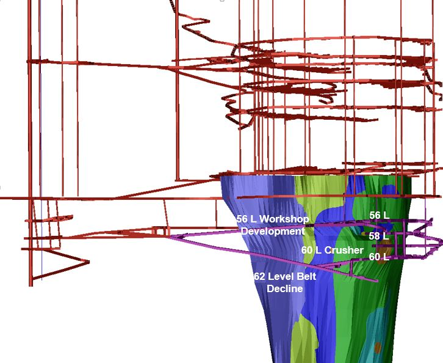

#### Assumptions

- Available data on the on-mine servers are of acceptable quality.
- Reader of this document has basic understanding of supervised learning and why these regression models were used.
- Reader has basic familiarity with sub-level cave mining.

#### Packages utilised

tidyr, caret, ranger, vtreat, xgboost, magrittr, ggplot2, dplyr, broom, knitr, rmarkdown, MultivariateRandomForest

#### Author

**Jacques Swart**

**Email address:** Jacques.swart@petradiamonds.com

### Loading

#### Objectives for this project

- Delineate best model that minimises the Root Mean Square Error (RMSE).
- Put model into production using (near) real-time data so that relevant stakeholders have sight on hourly prediction for the remaining shift and production day.
- Push under performing independent variables to screens for process control.

#### Dependent variable

- Buckets by hour

#### Data preparation

Prepared in SQL using:

```
- Loading data table from underground LHD monitoring system
- Employee scanner clocking System
- SQL-based production data
```

Based on above information the final train data was prepared and loaded into the workspace.

```r
# Read train data and inspect (February 2019)
KDMTrainCSV <- read.csv("~/GitHub/R/DataSets/KDMTrainCSV.csv")
str(KDMTrainCSV)
```

```
## 'data.frame':    696 obs. of  16 variables:
##  $ Instant            : int  1 2 3 4 5 6 7 8 9 10 ...
##  $ WeekDay            : int  6 6 6 6 6 6 6 6 6 6 ...
##  $ Hour               : int  6 7 8 9 10 11 12 13 14 15 ...
##  $ Operators          : int  8 11 11 11 11 11 11 11 5 3 ...
##  $ LHDs               : int  0 0 3 3 3 4 2 0 0 0 ...
##  $ FractionFrom56.W   : num  0 0 0 0 0 0 0 0 0 0 ...
##  $ FractionFrom58.E   : num  0 1 0.47 0.59 0.5 0.42 0 0 0 0 ...
##  $ FractionFrom58.R   : num  0 0 0 0 0 0 0 0 0 0 ...
##  $ FractionFrom60.E   : num  0 0 0.53 0.41 0.5 0.58 1 0 0 0 ...
##  $ FractionFrom60.W   : num  0 0 0 0 0 0 0 0 0 0 ...
##  $ DistinctTunnels56.W: int  0 0 0 0 0 0 0 0 0 0 ...
##  $ DistinctTunnels58.E: int  0 1 1 1 1 2 0 0 0 0 ...
##  $ DistinctTunnels58.R: int  0 0 0 0 0 0 0 0 0 0 ...
##  $ DistinctTunnels60.E: int  0 0 2 1 1 2 2 0 0 0 ...
##  $ DistinctTunnels60.W: int  0 0 0 0 0 0 0 0 0 0 ...
##  $ Buckets            : int  0 6 47 49 40 64 15 0 0 0 ...
```

```r
summary(KDMTrainCSV)
```

```
##     Instant         WeekDay           Hour         Operators
##  Min.   :  1.0   Min.   :1.000   Min.   : 0.00   Min.   : 0.00
##  1st Qu.:174.8   1st Qu.:2.000   1st Qu.: 5.75   1st Qu.: 8.75
##  Median :348.5   Median :4.000   Median :11.50   Median :12.00
##  Mean   :348.5   Mean   :4.078   Mean   :11.50   Mean   :10.15
##  3rd Qu.:522.2   3rd Qu.:6.000   3rd Qu.:17.25   3rd Qu.:13.00
##  Max.   :696.0   Max.   :7.000   Max.   :23.00   Max.   :22.00
##       LHDs       FractionFrom56.W FractionFrom58.E FractionFrom58.R
##  Min.   :0.000   Min.   :0.0000   Min.   :0.0000   Min.   :0.00000
##  1st Qu.:0.000   1st Qu.:0.0000   1st Qu.:0.0000   1st Qu.:0.00000
##  Median :2.000   Median :0.0000   Median :0.0000   Median :0.00000
##  Mean   :1.937   Mean   :0.1406   Mean   :0.1209   Mean   :0.02784
##  3rd Qu.:3.000   3rd Qu.:0.1900   3rd Qu.:0.1700   3rd Qu.:0.00000
##  Max.   :6.000   Max.   :1.0000   Max.   :1.0000   Max.   :1.00000
##  FractionFrom60.E FractionFrom60.W  DistinctTunnels56.W
##  Min.   :0.0000   Min.   :0.00000   Min.   :0.0000
##  1st Qu.:0.0000   1st Qu.:0.00000   1st Qu.:0.0000
##  Median :0.3300   Median :0.00000   Median :0.0000
##  Mean   :0.3618   Mean   :0.04437   Mean   :0.6882
##  3rd Qu.:0.7000   3rd Qu.:0.00000   3rd Qu.:1.0000
##  Max.   :1.0000   Max.   :1.00000   Max.   :4.0000
##  DistinctTunnels58.E DistinctTunnels58.R DistinctTunnels60.E
##  Min.   :0.0000      Min.   :0.0000      Min.   :0.0000
##  1st Qu.:0.0000      1st Qu.:0.0000      1st Qu.:0.0000
##  Median :0.0000      Median :0.0000      Median :1.0000
##  Mean   :0.3549      Mean   :0.1034      Mean   :0.9598
##  3rd Qu.:1.0000      3rd Qu.:0.0000      3rd Qu.:2.0000
##  Max.   :3.0000      Max.   :2.0000      Max.   :5.0000
##  DistinctTunnels60.W    Buckets
##  Min.   :0.000       Min.   : 0.00
##  1st Qu.:0.000       1st Qu.: 0.00
##  Median :0.000       Median :10.00
##  Mean   :0.227       Mean   :15.07
##  3rd Qu.:0.000       3rd Qu.:24.25
##  Max.   :2.000       Max.   :77.00
```

#### 2.4 Data visualisation

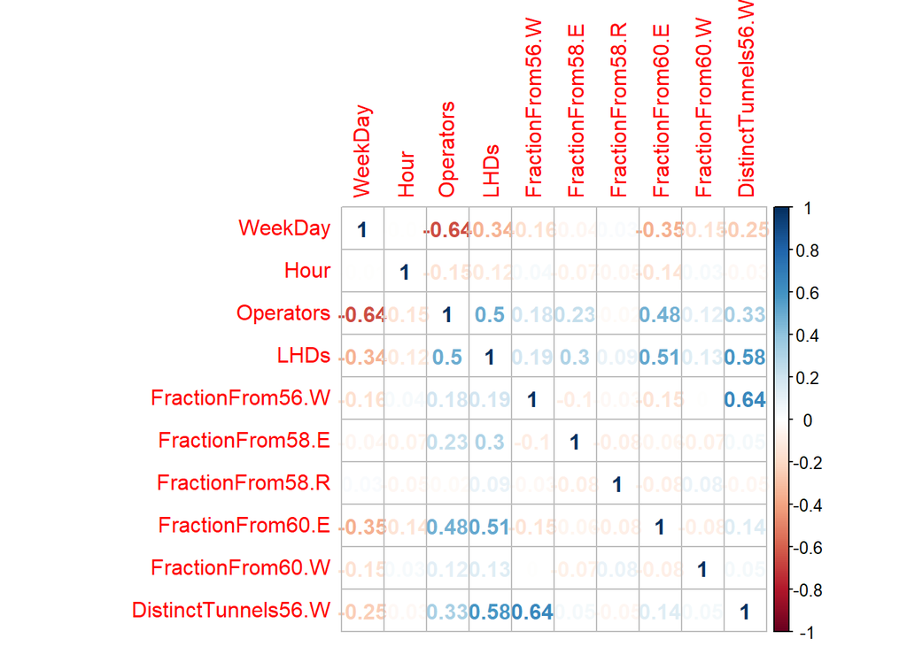

```r
# Understand correlation between variables
library(corrplot)
df<-as.matrix(KDMTrainCSV)
dfPairs <- df[,2:11]
dfPairs.cor<-cor(dfPairs)
corrplot(dfPairs.cor,method="number")
```

```r
# Load required libraries
library(magrittr)
library(dplyr)
```

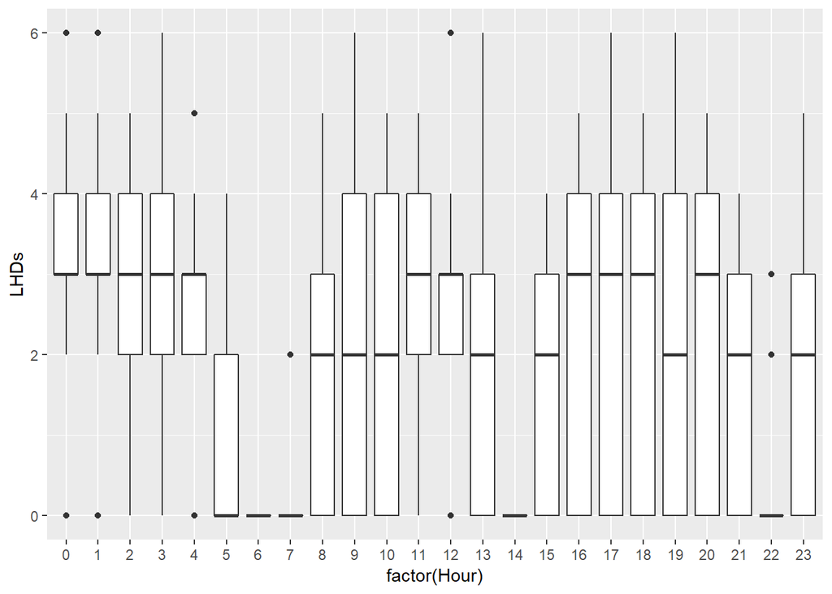

```r
library(ggplot2)
# Create data frame that groups the train data by hour
ByHourDF <- KDMTrainCSV %>%
group_by(Hour)
# Render distinct LHDs utilised by hour
ggplot(ByHourDF, aes(x=factor(Hour),y=LHDs))+geom_boxplot()
```

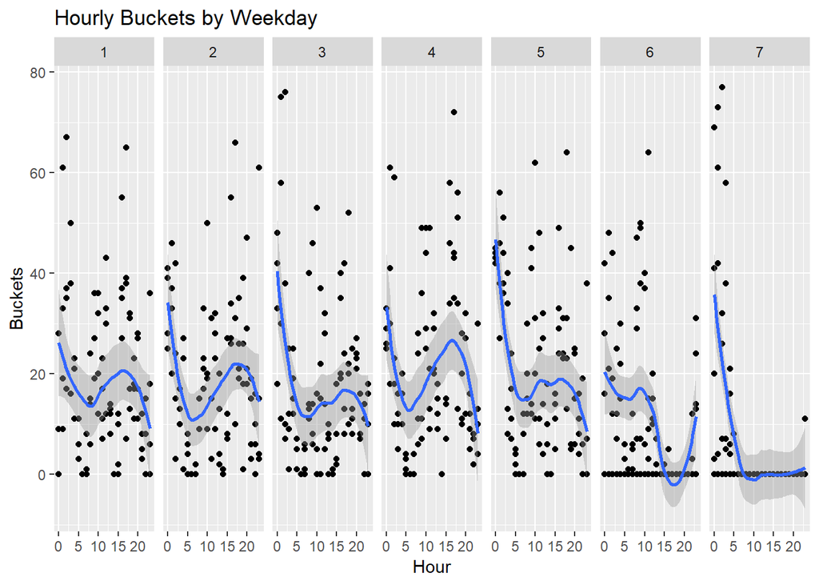

```r
# Render faceted graph showing buckets by week day by hour
  p1<-ggplot(data=KDMTrainCSV,aes(Hour,y=Buckets))+geom_point()+geom_smooth()
p1 +     facet_wrap( ~ WeekDay, nrow = 1) + theme(legend.position = "none") + ggtitle("Hourly Buckets by Weekday")
```

#### 2.5 Compare algorithms for fit on train and Test data

```r
mean(KDMTrainCSV$Buckets)
```

```
## [1] 15.0704
```

```r
var(KDMTrainCSV$Buckets)
```

```
## [1] 279.1389
```

var >> mean

Will therefore use Quasipoisson and not Poisson

Models:

- Model1 = Quasipoisson
- Model2 = Random forest
- Model3 - XGBoost

```r
# Test data as well (March 2019)
KDMTestCSV <- read.csv("~/GitHub/R/DataSets/KDMTestCSV.csv")
```

```r
# Model quasipoisson
formula <- KDMTrainCSV$Buckets~.-Instant
model1 <- glm(formula,data=KDMTrainCSV,family=quasipoisson)
# Predict on test data
pred1<-predict(model1,newdata=KDMTestCSV,type="response")
summary(pred1)
```

```
##     Min.  1st Qu.   Median     Mean  3rd Qu.     Max.
##  0.00501  0.00593  9.23929 13.00515 22.57643 76.40849
```

```r
# Calculate RMSE
KDMTestCSV %>%
mutate(residual = pred1 - Buckets) %>%
summarise(rmse=sqrt(mean(residual^2)))
```

| rmse |
| --- |
| 9.13453 |

```r
# Model random forest
library(ranger)
set.seed(1)
formula <- KDMTrainCSV$Buckets~.-Instant
model2 <- ranger(formula,KDMTrainCSV,num.trees=500,respect.unordered.factors = "order")
# Predict on test data
KDMTestCSV$pred2 <- predict(model2,KDMTestCSV)$predictions
summary(KDMTestCSV$pred2)
```

```
##    Min. 1st Qu.  Median    Mean 3rd Qu.    Max.
##  0.0700  0.2485 11.6190 12.8582 21.3399 50.4560
```

```r
# Calculate RMSE
KDMTestCSV %>%
mutate(residual = pred2 - Buckets) %>%
summarise(rmse=sqrt(mean(residual^2)))
```

| rmse |
| --- |
| 9.43832 |

```r
# Model XGBoost
library(xgboost)
library(vtreat)
set.seed(1)
(outcome <- "Buckets")
```

```
## [1] "Buckets"
```

```r
(vars <- c("Weekday", "Hour", "Operators", "LHDs", "X56.W","X58.E","X58.R","X60.E","X60.W"))
```

```
## [1] "Weekday"   "Hour"      "Operators" "LHDs"      "X56.W"     "X58.E"
## [7] "X58.R"     "X60.E"     "X60.W"
```

```r
treatplan <- designTreatmentsZ(KDMTrainCSV,vars,verbose = FALSE)
# Get the "clean" and "lev" variables from the scoreFrame
(newvars <- treatplan %>%
use_series(scoreFrame) %>%
filter(code %in% c("clean","lev")) %>%
use_series(varName))
```

```
## [1] "Hour"      "Operators" "LHDs"
```

```r
# Prepare data  frames with new variables
KDMTrainCSV.treat <- prepare(treatplan,KDMTrainCSV, varRestriction = newvars)
KDMTestCSV.treat <- prepare(treatplan,KDMTestCSV, varRestriction = newvars)
#
cv <- xgb.cv(data = as.matrix(KDMTrainCSV.treat),
label = KDMTrainCSV$Buckets,
nrounds = 100,
nfold = 5,
objective = "reg:linear",
eta = 0.3,
max_depth = 6,
early_stopping_rounds = 10,
verbose = 0   # silent
)
# Get evaluation log
elog <- cv$evaluation_log
#Detrmine amount of trees minimising trees for train and test
elog %>%
summarize(ntrees.train = which.min(train_rmse_mean),   # find the index of min(train_rmse_mean)
ntrees.test  = which.min(test_rmse_mean))    # find the index of min(test_rmse_mean)
```

| ntrees.train | ntrees.test |
| --- | --- |
| 19 | 9 |

```r
#Use optimal tree

Buckets_model_xgb <- xgboost(data = as.matrix(KDMTrainCSV.treat), # training data as matrix
label = KDMTrainCSV$Buckets,  # column of outcomes
nrounds = 24,       # number of trees to build
objective = "reg:linear", # objective
eta = 0.3,
depth = 6,
verbose = 0  # silent
)
# Make predictions
KDMTestCSV$pred3 <- predict(Buckets_model_xgb,as.matrix(KDMTestCSV.treat))
# Calculate RMSE
KDMTestCSV %>%
mutate(residual = pred3 - Buckets) %>%
summarise(rmse=sqrt(mean(residual^2)))
```

| rmse |
| --- |
| 12.03676 |

#### 2.6 Visualise prediction versus actuals for test data

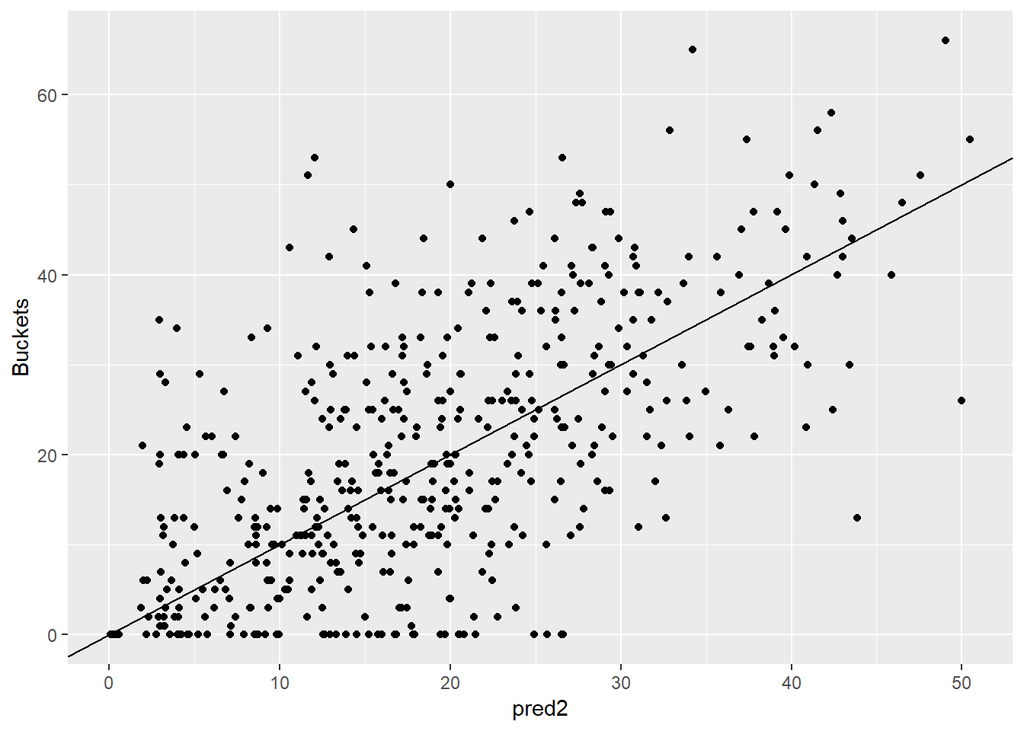

```r
#Plot prediction versus actual for test data
ggplot(KDMTestCSV, aes(x=pred2,y=Buckets))+
geom_point()+
geom_abline()
```

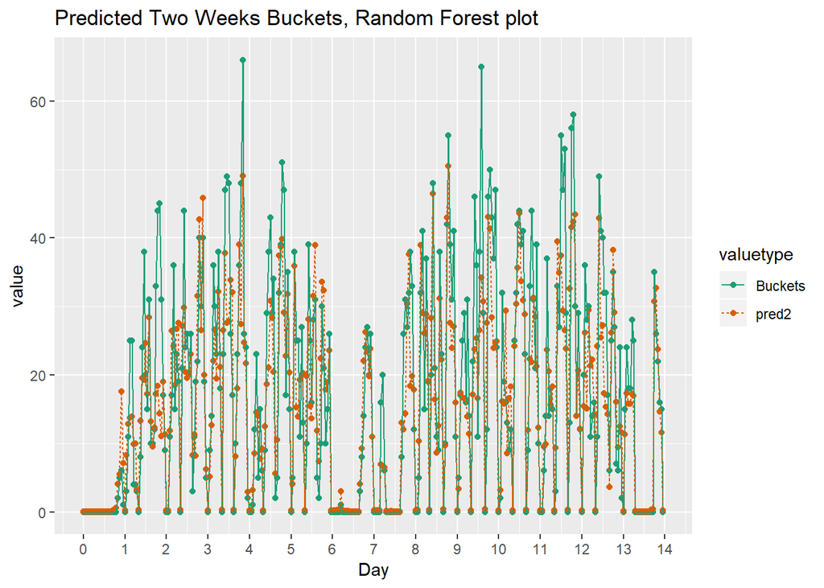

```r
#Plot prediction versus actual for test data example
library(tidyr)
# Week
first_two_weeks <- KDMTestCSV %>%
  # Set start to 0, convert unit to days
  mutate(Instant = (Instant - min(Instant)) / 24) %>%
  # Gather Buckets and pred2 into a column named value with key valuetype
  gather(key = valuetype, value = value, Buckets, pred2) %>%
  # Filter for rows
  filter(Instant < 14 )

# Plot predictions and Buckets by date/time
ggplot(first_two_weeks, aes(x = Instant, y = value, color = valuetype, linetype = valuetype)) +
  geom_point() +
  geom_line() +
  scale_x_continuous("Day", breaks = 0:14, labels = 0:14) +
  scale_color_brewer(palette = "Dark2") +
  ggtitle("Predicted Two Weeks Buckets, Random Forest plot")
```

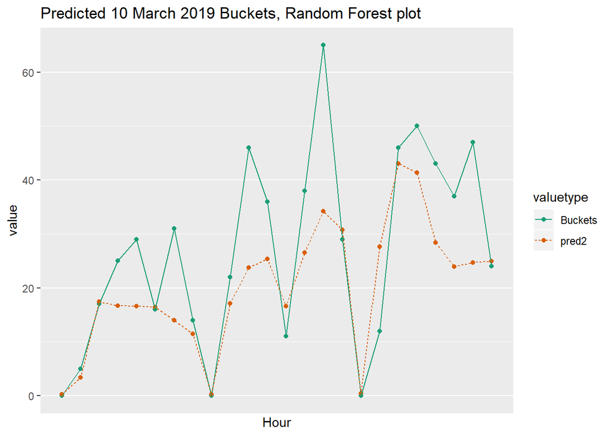

```r
# Specific day: 10 March 2019
Specific_day <- KDMTestCSV %>%
  # Set start to 0, convert unit to days
  mutate(instant = (Instant - min(Instant))) %>%
  # Gather Buckets and pred2 into a column named value with key valuetype
  gather(key = valuetype, value = value, Buckets, pred2) %>%
  # Filter for rows
  filter(Instant <= 10*24 & Instant > 9*24)

#Plot predictions and Buckets by date/time
ggplot(Specific_day, aes(x = Instant, y = value, color = valuetype, linetype = valuetype)) +
  geom_point() +
  geom_line() +
  scale_x_continuous("Hour", breaks = 0:14, labels = 0:14) +
  scale_color_brewer(palette = "Dark2") +
  ggtitle("Predicted 10 March 2019 Buckets, Random Forest plot")
```

The model that has been inferred makes it possible to predict on hourly data. It will be put into production using SQLMachine learning services. The current hour’s prediction will be based on the real-time quantities of the independent variables.

The remaining hours of the production day will be predicted using the last two rolling month’s average for the quantity of operators and the quantity of LHDs for each hour on each weekday. The percentage extraction from each level and orientation will be based on the split of the called tonnes by the planner before each production day. Drilling meters by level will be actuals.